# JSC370 Midterm

2024-03-05

## Introduction

In recent years there has been an increasing pessimism about the prospect of owning a home, with younger generations dissatisfied how older generations own homes well they cannot afford to. Younger generations may question whether they will ever be able to own their own homes, and compare themselves to the seemingly far favorable conditions for older generations; indeed, home ownership and housing affordability is often cited as a core issue for younger generations [3].

The goal of this project is to examine differences in home ownership between generations through home ownership rates by year, age, and locations. The proposed research question is: Have home ownership rates in the United States changed between the generations of Baby Boomers, Gen X, Millenials, and Gen Z?

The dataset that was used to answer this question is a subset of the IPSUM CPS dataset. The dataset comes from the United States Census Current Population Survey (CPS) and its supplemental Annual Social and Economic Supplement survey (ASEC). The CPS is preformed monthly to different households in the US while the ASEC supplement is preformed annualy in March. The dataset contains both household and individual level information, meaning some variables refer to entire household information such as whether a house is owned or rented, while other variables refer to individual information such as a persons age.

As the entire IPUMS CPS dataset is large and contains many variables that are irrelevant to this analysis, a subset of the data was used containing only the variables and year range of interest described in the methods section.

## Methods

The methods section includes subsections corresponding to how the data was obtained, data cleaning, data wrangling, and the methods for how the plots were produced.

### Data Collection

IPUMS CPS allows users to create their own subsets, called data extracts, of the full CPS dataset that contain variables and year ranges of interest. To create a data extract, a user must select variables and year ranges and then wait for a data extract to be generated; once the extract is generated it can be downloaded. The creation and retrieval of the data extract used in this analysis was preformed through the IPUMS API. To create the extract through the API, a post request was made using the httr R package with a formatted JSON string that specified the year range and variables of interest. The year range was 1976-2023 and the variables of interest were:

-YEAR which is the year an observation was from

-AGE which is the age of an individual,

-OWNERSHIP which is whether the household that an individual belongs to is rented/owned,

-RELATE which is the relation to their relation to the householder of the household an individual belongs to

-STATEFIP which is the FIP code of the state were the observation was from

-COUNTY which is the FIP code of the county were the observation was from

Once the data extract request was submitted, a get request was used to check whether the data extract had been generated. Finally, when the data extract was complete, the data files were downloaded from the URLs provided from the content of the get request. The dataset was then loaded in R using the ipumsr package provided by IPUMS for loading IPUMS data into R.

In addition to the key variables mentioned in the introduction, IPUMS provides weights for calculating individual and household level statistics to mitigate the sampling bias of the the survey, these weights were also included in the dataset as the variables ASECWTH for household level statistics and ASECWT for individual level statistics.

### Data Cleaning

Once the dataset was loaded into R, it’s dimensions were checked for how many observations were present in the dataset and whether the number of variables was consistent with what was requested in the data extract. Checking the dimension showed that the dataset contains 8,293,750 observations with each observation being an individual who belongs to a household. The head, tail, and variable types were also checked to make sure the dataset was imported correctly.

Once the dataset was confirmed to have been imported correctly, the variables were checked for missing values and suspicious values. All values for AGE, YEAR, RELATE, OWNERSHP, and STATEFIP had no missing values and were all in their expected range; however, the variable COUNTY had 3,159,092 missing values and 2,991,865 values of 0 which is not a recognized county FIP code. Checking the IPUMS data dictionary confirmed that a value of 0 was used for counties that did not meet a population threshold due to concerns about deanonymizing data. Further investigation also showed that all the missing values in the COUNTY variable occurred before 1995. Removing observations with missing values for COUNTY would remove a significant amount of the data. Additionally, the COUNTY variable was not used across most of the analysis; therefore, no observations were removed.

Something to note in the dataset is that the values in the categorical variables are given by codes that correspond to their meaning, for example, the variable OWNERSHIP has a value of “10” when the observation belongs to a household that is owned. The meaning of these codes is easy to find on the IPUMS CPS website, so these values were not changed in this analysis.

### Data Wrangling

The number of observations with age >90 were small which created outliers in the home ownership rates within these age ranges. Additionally, In the United States, people cannot own property until they reach the age of majority which is 19 in some states. Therefore, the age ranges of <19 and >90 were removed from the data set. After removing all observations with age less than 19 and greater than 90 there were 5,796,909 observations left. Removing these entries means that the population of interest in this analysis are adults in the United States between the ages of 19 and 90.

### Methods for Analysis

Once the data cleaning and wrangling was complete, the analysis could be preformed. To answer the research question, home ownership rates had to be calculated across generations. For this analysis, a home ownership rate was defined:

$$\text{Home Ownership Rate (%)} = 100
\cdot \frac{\text{Owner Occupied Households}}{\text{Total Occupied
Households}}$$

This definition is consistent the definition given by the Census Housing Vacancy Survey [2]. As the dataset provides weights for calculating household level statistics, the home ownership rate was calculated as the the sum of the weights associated with an owner occupied household divided by the sum of weights associated with an occupied household. Finally, a generations home ownership rate is calculated the same, except only households owned/occupied by an individual in that generation are counted.

To find owner occupied households within the dataset both the OWNERSHP and RELATE variable had to be used. The OWNERSHP variable in the dataset refers to whether the household the observation belongs to is owned or rented; this does not mean that the individual is a homeowners as, for example, an individual living with parents who own a home would have a value of ownership rather than rented in the OWNERSHIP variable. Instead, both the variables OWNERSHP and RELATE have to be used to find homeowners. If OWNERSHP indicates that the observation belong to a household that owns their home and RELATE indicates that the observation is the householder then that observation is considered a homeowner.

Finally, visualizations and summaries were created to explore the differences in homeownership rates between generations.

First, table summaries were created to show homeownership rates by generation in different years and at different ages. To create the table of homeownership rate by year between generations, homeownership rates were calculated for each year grouped by generation. To create the table of homeownership rate by age between generations, homeownership rates were calculated for each age grouped by generation; for example, the homeownership rate for 25 year old Baby Boomers would be calculated using only observations were the age was 25 and the observation was a Baby Boomer (these would be from years between 1971-1989).

To further explore the trend of homeownership rate over time, a line chart was created to show homeownership by year with a trend line for each generation. Similarly, to explore the trend of homeownership by age, a line chart was created to show homeownership by age with a trend line for each generation.

To explore difference in homeownership in locations by generation, a map visualization was created to show home ownership at the state level, and at the county level. To create these map visualizations, geojson files of USA state and county maps that included FIPS data were used. Home ownership rates were calculated by state/county and then this data was merged into the geojson files using the FIPS codes. For the county map, some counties were not identified, these counties were merged together within state borders to form a map that contained homeownerhip rates in all identified counties, and home ownership rates in states not including identified counties within the state. Similarly, any county with <50 observations in any generation was combined with the non-identified counties within state borders.

## Preliminary Results

| YEAR | Baby Boomer | Gen X | Gen Z | Millenial |
| --- | --- | --- | --- | --- |
| 2018 | 76.94919 | 66.50245 | 21.25693 | 40.61062 |
| 2019 | 77.22946 | 66.92789 | 22.49573 | 43.23064 |
| 2020 | 78.74693 | 69.01683 | 22.56327 | 47.94009 |
| 2021 | 78.47346 | 69.02732 | 23.36040 | 48.67208 |
| 2022 | 77.82291 | 69.72024 | 25.71410 | 51.45640 |
| 2023 | 77.99646 | 71.36857 | 25.87277 | 54.23662 |

| AGE | Baby Boomer | Gen X | Gen Z | Millenial |
| --- | --- | --- | --- | --- |
| 25 | 31.25654 | 26.84121 | 28.95171 | 27.38984 |
| 30 | 50.61442 | 48.34606 | NA | 42.27259 |
| 35 | 60.50193 | 58.64897 | NA | 55.59943 |
| 40 | 67.73174 | 63.52479 | NA | 61.27793 |

This table shows the homeownership rates at certain ages by generation. As the oldest members of Gen Z were only 26 in 2023, their is no data available in the later ages. We can see that Baby Boomers have the highest home ownership rate at all ages while Millennials have the lowest across all ages except 25. While Gen Z only has data at the age 25, it has the second highest home ownership rate at this age. There does appear to be a trend of homeownership rates dropping at all ages as the generations get younger; however, Gen Z could disrupt this trend if their rates continue to be high. Without further data on Gen Z, we cannot know if this trend will continue or Gen Z will outperform Millennials and/or Gen X.

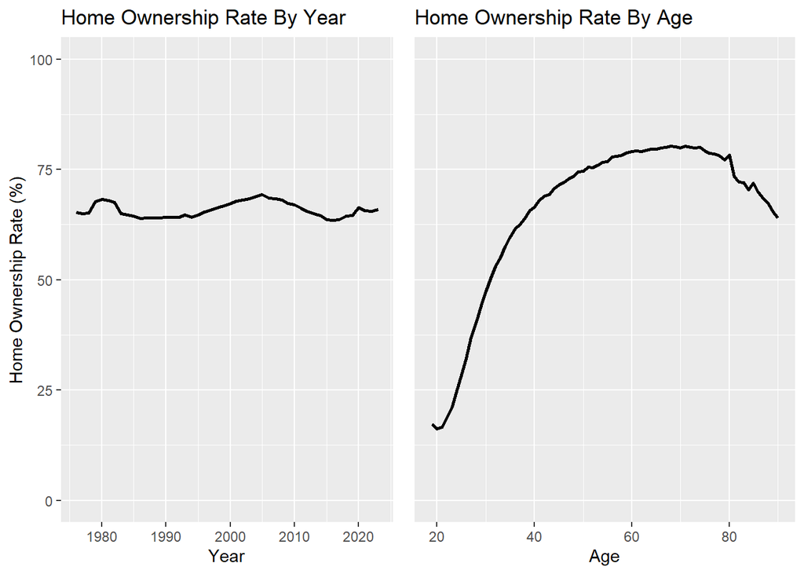

These plots show overall trends of home ownership by year and age. We can see that home ownership rates tend to stay fairly similar over time. This makes sense as outside of large economic shifts we would expect to have the proportion of people owning homes stay fairly constant as younger people buy houses and older people move out.We can also see that home ownership rates by age increases over time and then starts to flatten out around 50, before starting to decrease at around 80. Again, this would make sense as people would want to buy homes once they have a stable income and career which would likely occur in the age range 25-40. Then since most people who had the means to buy a house or wanted to buy a house likely already did by 50, the rate starts to flatten. Finally, once a person is older, they may start to sell their homes and move in with family or care home. Interestingly, we also see an outlier at around 19 where the rate starts off higher. The slightly elevated rate at 19 could be due to inheritance where an individual is not legally allowed to own a property until they reach age of majority.

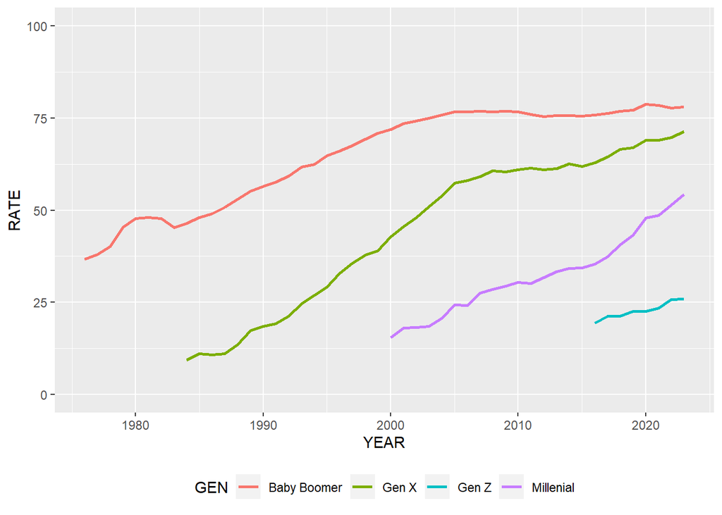

This plot shows the trend of home ownership by year between each generation. We can see that Baby Boomer rate is has flattened significantly since around 2005 and the Gen X was starting to flatten around 2005 as well although it has started to increase again since around 2015; the sub prime mortgage crisis occurred between 2007 and 2010 and could have contributed to this decrease in the rate of change of the Gen X home ownership rate. For Millennials, we can see that the rate has been increasing and is starts to increase faster around 2015. Finally, for Gen Z there is not a lot of data, but we can see that it is starting to increase and in 2020 it had the rate started to increase faster.

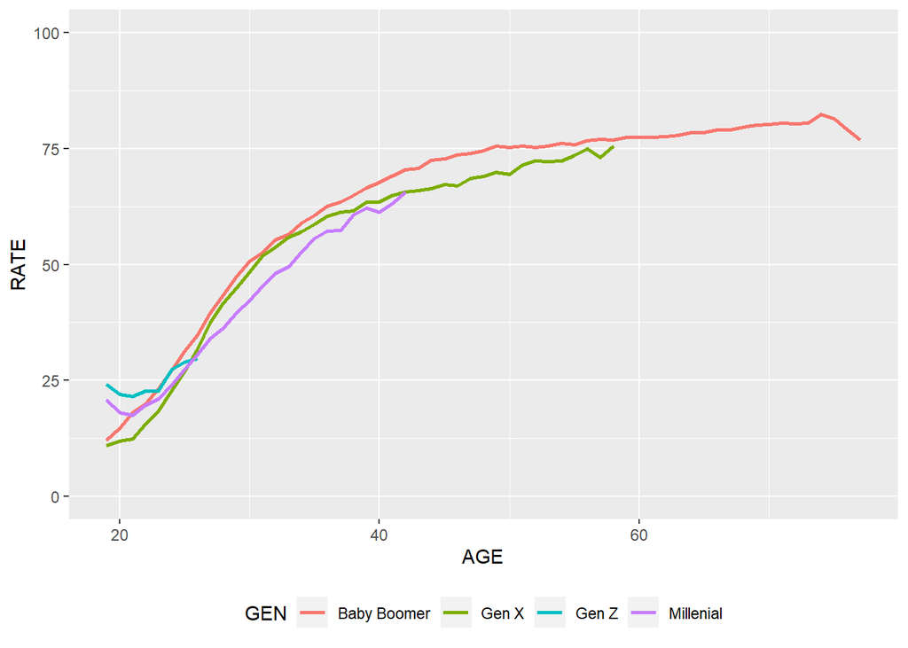

This plot shows the trend of home ownership by age between each generation. The plot provides a good comparison of home ownership rates by generation. We can see that Baby Boomers have consistently outperformed all other generations past the age of 26 and we can also see that Millenials have under preformed all other generations past the age of 26. The Gen X rate tracks fairly closely to the Baby Boomer rate before it starts to under preform in the 30s age range and onward. Gen Z out preforms both Millennial and Gen X for the age range where data is available, while the Gen Z line flattens towards the age of 26, without further data we do not know whether Gen Z will outperform or under preform other generations. Low intrest rates from 2019-2021, when older members of Gen Z would have started thinking about buying a home, could have contributed to the high home ownership rates of Gen Z relative to the other generations.

[interactive chart not shown]

This map shows home ownership rates by state and generation. We can see that Baby Boomers have fairly high home ownership rates across all states. The states with the lowest home ownership rates for Baby Boomers are California, New York, and Hawaii. For Gen X, we see lower home ownership than Baby Boomers. We also see that Midwestern states and non-coastal states tend to have higher home ownership rates, which could be due to affordability. For Millennials, we can see again that home ownership is lower than Gen X, but we also see that the states with the lowest home ownership rates are similar to the states with the lowest home ownership rates for Gen Z. Finally, for Gen Z the states with the lowest home ownership rates are fairly similar to Millenials and Gen X, but surprisingly Florida is one of the states with the highest home ownership rate which is unique to Gen Z.

[interactive chart not shown]

Similar to the previous map, this map shows home ownership rates by geography and generation. This map includes counties that were identified in the dataset, many counties were not identified in the dataset as their population was below a threshold were there are concerns about deanonymizing the data. All counties that were not identified in the dataset and any county with less than 50 observations in any generation are combined into the state and labeled “State w/o Counties”. Similar patterns can be seen to the previous state map; however, the difference between urban and rural home ownership rates are more obvious in this map, with rural areas tending to have higher home ownership rates across all generations.

## Summary

The analysis compared home ownership rates across generations by investigating trends in home ownership rate over time, age, and geography.

The trend of home ownership rate over years between generations was similar, with fast growth followed by a flattening of the curve; however, some differences between home ownership rate over year trend could be seen, such as the increase in Gen X home ownership rate slowing down between the years 2005 and 2015, potentially due to housing market conditions in this period. While some differences were present, the overall trends appeared similar, showing that the trend home ownership rate over time has not significantly changed between generations.

The trend of home ownership rate over age between generations was also similar. Although some deviations could be seen in the trends between generations. Millennials tended to have the lowest home ownership rates at all ages when compared to the other generations, while Baby Boomers tended to have the highest rates at all ages. Gen X tracked closely with Baby Boomer between the ages 19-35 but started to under preform at later ages. Surprisingly, Gen Z was had the highest home ownership rates in ages 19-23 and the second highest in ages 23-26 with Baby Boomers as the highest in that age range. The trends between each generation being similar and the high home ownership rates of Gen Z indicate that home ownership has not increased or declined significantly between generations despite Baby Boomers and Gen X tending to have higher rates.

The analysis of home ownership rates by state and by county showed that home ownership rates tended to be similar across geography between the generations. Home ownership rates in less populous states and counties, such as Midwestern states or non-identified counties, tended to be higher across all generations; although there were some interesting differences, such as Florida being one of the states with the highest home ownership rate for Gen Z compared to all other generations were Florida was not one of the states with high home ownership rate.

Overall, the analysis showed that home ownership rates by year, age, and geography have remained fairly similar between generations. Although the home ownership rates do not appear to have increased or declined significantly, this does not necessarily mean the housing market remained the same. This analysis does not take into account any income, mortgage rates, or pricing data, so it cannot give an accurate picture of the housing market or housing affordability. Further analysis that include more economic data would provide more cohesive information about housing market between generations.

## Citations:

IPUMS: Sarah Flood, Miriam King, Renae Rodgers, Steven Ruggles, J. Robert Warren, Daniel Backman, Annie Chen, Grace Cooper, Stephanie Richards, Megan Schouweiler, and Michael Westberry. IPUMS CPS: Version 11.0 [dataset]. Minneapolis, MN: IPUMS, 2023. https://doi.org/10.18128/D030.V11.0

Generation Ranges:

[1] Dimock, M. (2019, January 17). Defining generations: Where millennials end and generation Z begins. Pew Research Center. https://www.pewresearch.org/short-reads/2019/01/17/where-millennials-end-and-generation-z-begins/

Home Ownership Definition:

[2] Definitions and Explanations. United States Census. https://www.census.gov/housing/hvs/definitions.pdf

Home Ownership as a voting issue:

[3] O’Donnell, K. (2022, August 2). Young people are pissed off: Housing crush sours millennial voters. Politico. https://www.politico.com/news/2022/08/02/housing-millennials-biden-economy-00047704

Geojson for states:

https://rstudio.github.io/leaflet/json/us-states.geojson

Geojson for counties:

https://gist.github.com/sdwfrost/d1c73f91dd9d175998ed166eb216994a